# Multi Omic Data explioration

Edmond Géraud Aguilar

17 de mayo, 2021

```r
> library(GEOquery)
> library(ggplot2)
> library(limma)
> library(DESeq2)
> library(Rsubread)
> library(data.table)
> library(edgeR)
> library(ggrepel)
> library(sva)
> library(MOFA2)
> library(MOFAdata)
> library(data.table)
> library(BloodCancerMultiOmics2017)
> library(ExperimentHub)
> library(SummarizedExperiment)
> library(CLLmethylation)
> library(minfi)
> library(PCAtools)
> library(survival)
> library(ggfortify)
> library(reshape2)
> library(survival)
> library(ggcorrplot)
> library(VennDiagram)
> library(plotrix)
> library(survminer)
> library(SurvCorr)
> library(tidyverse)
> library(dplyr)
> library(papeR)
```

# 1 Data

Chronic Lymphocytic Leukemia cohort.

measured ex vivo sensitivity of 246 blood cancers to 63 drugs alongside genome, transcriptome, and DNA methylome analysis to understand determinants of drug response. We profiled 246 patient and 3 control samples with 64 drugs.

# 2 Why ? Objective

Insights between DNA mehtylation profiles and expression profiles with CLL patients. Treated and no treated with drugs. There are patients with trysomy 12 and immunoglobulin heavy chain variable gene locvi in chromosome 14.

```r
> utils::data("CLL_data")
> lapply(CLL_data, dim)
```

```
$Drugs
[1] 310 200

$Methylation
[1] 4248  200

$mRNA
[1] 5000  200

$Mutations
[1]  69 200
```

```r
> MOFAobject <- create_mofa(CLL_data)
```

```
Creating MOFA object from a list of matrices (features as rows, sample as columns)...
```

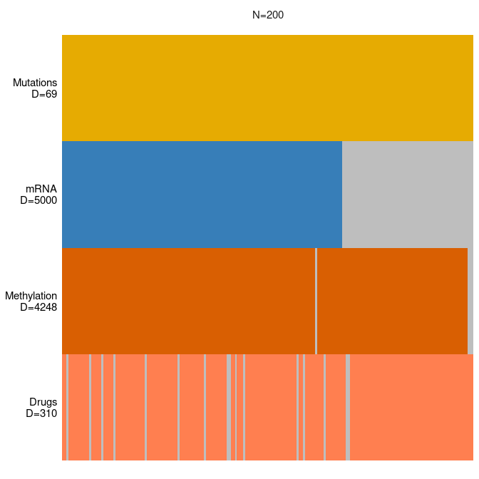

```r
> plot_data_overview(MOFAobject)
```

Gender: m (male), f (female) Age: age in years TTT: time (in years) which passed from taking the sample to the next treatment TTD: time (in years) which passed from taking the sample to patients’ death treatedAfter: (TRUE/FALSE) Died: whether the patient died (TRUE/FALSE)

```r
> CLL_metadata <- fread("ftp://ftp.ebi.ac.uk/pub/databases/mofa/cll_vignette/sample_metadata.txt")
```

# 3 Metadata Analysis

First we eliminate those samples with missing values in the metadata, though MOFA handles missing values

```r
> CLL_metadata.copy <- as.data.frame(CLL_metadata)
> rownames(CLL_metadata.copy) <- CLL_metadata.copy$sample
> CLL_metadata.copy <- CLL_metadata.copy[, -1]
> CLL_metadata.copy$Gender <- as.factor(CLL_metadata.copy$Gender)
> CLL_metadata.copy$treatedAfter <- as.factor(CLL_metadata.copy$treatedAfter)
> CLL_metadata.copy$died <- as.factor(CLL_metadata.copy$died)
> CLL_metadata.copy$IGHV <- as.factor(CLL_metadata.copy$IGHV)
> CLL_metadata.copy$trisomy12 <- as.factor(CLL_metadata.copy$trisomy12)
>
> levels(CLL_metadata.copy$treatedAfter) <- c("Treat", "NoTreat")
> levels(CLL_metadata.copy$died) <- c("L", "D")  #L live D death
> levels(CLL_metadata.copy$IGHV) <- c("NOmut", "mut")
> levels(CLL_metadata.copy$trisomy12) <- c("norm", "tri")
> CLL_metadata.copy$sample <- paste(rownames(CLL_metadata.copy),
+     CLL_metadata.copy$Gender, CLL_metadata.copy$treatedAfter,
+     CLL_metadata.copy$died, CLL_metadata.copy$IGHV, CLL_metadata.copy$trisomy12,
+     sep = "_")
> discard <- apply(CLL_metadata.copy, 1, function(x) any(is.na(x)))
> CLL_metadata.copy <- CLL_metadata.copy[!discard, ]
> head(CLL_metadata.copy)
```

```
     Gender      age         TTT       TTD treatedAfter died  IGHV trisomy12
H005      m 75.26575 0.574948665 2.6255989      NoTreat    L   mut      norm
H010      f 72.78082 2.932238193 2.9322382        Treat    L NOmut      norm
H011      f 72.99452 0.019164956 2.9514031      NoTreat    L   mut      norm
H012      f 61.69863 0.128678987 0.7255305      NoTreat    D NOmut      norm
H013      m 77.46301 0.002737851 0.8021903      NoTreat    D NOmut      norm
H014      f 86.16712 0.136892539 1.5797399      NoTreat    D NOmut      norm
                          sample
H005   H005_m_NoTreat_L_mut_norm
H010   H010_f_Treat_L_NOmut_norm
H011   H011_f_NoTreat_L_mut_norm
H012 H012_f_NoTreat_D_NOmut_norm
H013 H013_m_NoTreat_D_NOmut_norm
H014 H014_f_NoTreat_D_NOmut_norm
```

```r
> str(CLL_metadata.copy)
```

```
'data.frame':   152 obs. of  9 variables:
 $ Gender      : Factor w/ 2 levels "f","m": 2 1 1 1 2 1 1 2 2 1 ...
 $ age         : num  75.3 72.8 73 61.7 77.5 ...
 $ TTT         : num  0.57495 2.93224 0.01916 0.12868 0.00274 ...
 $ TTD         : num  2.626 2.932 2.951 0.726 0.802 ...
 $ treatedAfter: Factor w/ 2 levels "Treat","NoTreat": 2 1 2 2 2 2 2 1 2 2 ...
 $ died        : Factor w/ 2 levels "L","D": 1 1 1 2 2 2 1 1 2 2 ...
 $ IGHV        : Factor w/ 2 levels "NOmut","mut": 2 1 2 1 1 1 1 2 1 1 ...
 $ trisomy12   : Factor w/ 2 levels "norm","tri": 1 1 1 1 1 1 2 2 1 1 ...
 $ sample      : chr  "H005_m_NoTreat_L_mut_norm" "H010_f_Treat_L_NOmut_norm" "H011_f_NoTreat_L_mut_norm" "H012_f_NoTreat_D_NOmut_norm" ...
```

```r
> CLL_metadata.survival <- CLL_metadata.copy
```

## 3.1 Descriptive statistics (por hacer)

|  | Level |  | N | % | $\sum$ % |  | N | % | $\sum$ % |
| --- | --- | --- | --- | --- | --- | --- | --- | --- | --- |
| Gender | f |  | 25 | 36.2 | 36.2 |  | 38 | 45.8 | 45.8 |
|  | m |  | 44 | 63.8 | 100.0 |  | 45 | 54.2 | 100.0 |
| died | L |  | 69 | 100.0 | 100.0 |  | 65 | 78.3 | 78.3 |
|  | D |  | 0 | 0.0 | 100.0 |  | 18 | 21.7 | 100.0 |
| IGHV | NOmut |  | 18 | 26.1 | 26.1 |  | 49 | 59.0 | 59.0 |
|  | mut |  | 51 | 73.9 | 100.0 |  | 34 | 41.0 | 100.0 |
| trisomy12 | norm |  | 57 | 82.6 | 82.6 |  | 70 | 84.3 | 84.3 |
|  | tri |  | 12 | 17.4 | 100.0 |  | 13 | 15.7 | 100.0 |

|  |  | treatedAfter |  | N |  | Mean | SD |  | Min | Q1 | Median | Q3 | Max |
| --- | --- | --- | --- | --- | --- | --- | --- | --- | --- | --- | --- | --- | --- |
| 1 | age | Treat |  | 69 |  | 67.08 | 11.56 |  | 41.77 | 58.21 | 66.70 | 75.17 | 88.19 |
| 1.1 |  | NoTreat |  | 83 |  | 65.69 | 11.73 |  | 33.87 | 57.48 | 68.25 | 73.57 | 90.73 |
| 2 | TTT | Treat |  | 69 |  | 1.67 | 0.87 |  | 0.00 | 1.01 | 1.58 | 2.43 | 3.37 |
| 2.1 |  | NoTreat |  | 83 |  | 0.37 | 0.48 |  | 0.00 | 0.05 | 0.18 | 0.42 | 2.13 |
| 3 | TTD | Treat |  | 69 |  | 1.67 | 0.87 |  | 0.00 | 1.01 | 1.58 | 2.43 | 3.37 |
| 3.1 |  | NoTreat |  | 83 |  | 1.61 | 0.83 |  | 0.10 | 0.97 | 1.46 | 2.24 | 3.99 |

## 3.2 Survival Analysis

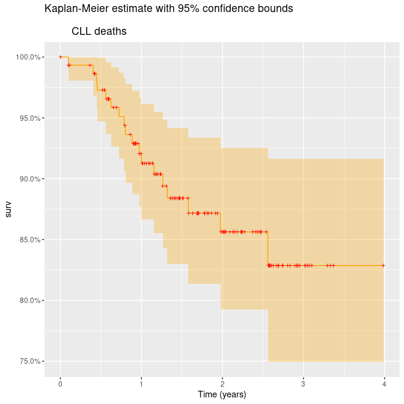

```r
> CLL_metadata.survival$survivalOutcome <- Surv(time = CLL_metadata.survival$TTD,
+     event = CLL_metadata.survival$died == "D")
>
> my.death <- survfit(CLL_metadata.survival$survivalOutcome ~ 1)
> autoplot(my.death, surv.colour = "orange", censor.colour = "red",
+     main = "Kaplan-Meier estimate with 95% confidence bounds\n
+          CLL deaths",
+     xlab = "Time (years)")
```

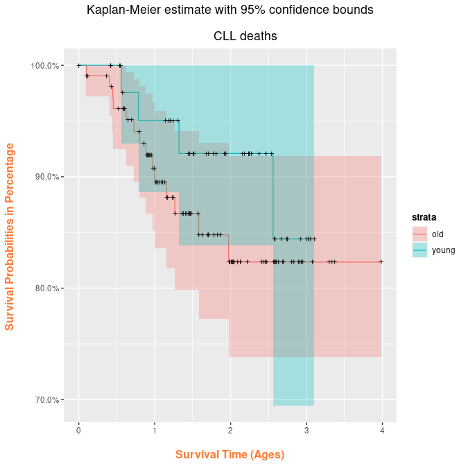

```r
> CLL_metadata.survival$grouping_age <- rep("young", nrow(CLL_metadata.survival))
> CLL_metadata.survival$grouping_age[CLL_metadata.survival$age >=
+     60] <- "old"
> my.fit <- survfit(CLL_metadata.survival$survivalOutcome ~ as.factor(CLL_metadata.survival$grouping_age))
> autoplot(my.fit) + labs(x = "\n Survival Time (Ages) ", y = "Survival Probabilities in Percentage \n",
+     title = "Kaplan-Meier estimate with 95% confidence bounds\n
+          CLL deaths") +
+     theme(plot.title = element_text(hjust = 0.5), axis.title.x = element_text(face = "bold",
+         colour = "#FF7A33", size = 12), axis.title.y = element_text(face = "bold",
+         colour = "#FF7A33", size = 12), legend.title = element_text(face = "bold",
+         size = 10))
```

```r
> survdiff(CLL_metadata.survival$survivalOutcome ~ as.factor(CLL_metadata.survival$grouping_age))
```

```
Call:
survdiff(formula = CLL_metadata.survival$survivalOutcome ~ as.factor(CLL_metadata.survival$grouping_age))

                                                      N Observed Expected
as.factor(CLL_metadata.survival$grouping_age)=old   107       14    12.12
as.factor(CLL_metadata.survival$grouping_age)=young  45        4     5.88
                                                    (O-E)^2/E (O-E)^2/V
as.factor(CLL_metadata.survival$grouping_age)=old       0.291     0.895
as.factor(CLL_metadata.survival$grouping_age)=young     0.600     0.895

 Chisq= 0.9  on 1 degrees of freedom, p= 0.3
```

We do not observe any differences between yound and old patients with CLL in deaths in survival analysis

Let’s perform a survival analysis on the tratment, if they were trated or not, and also the differences between old and young patients.

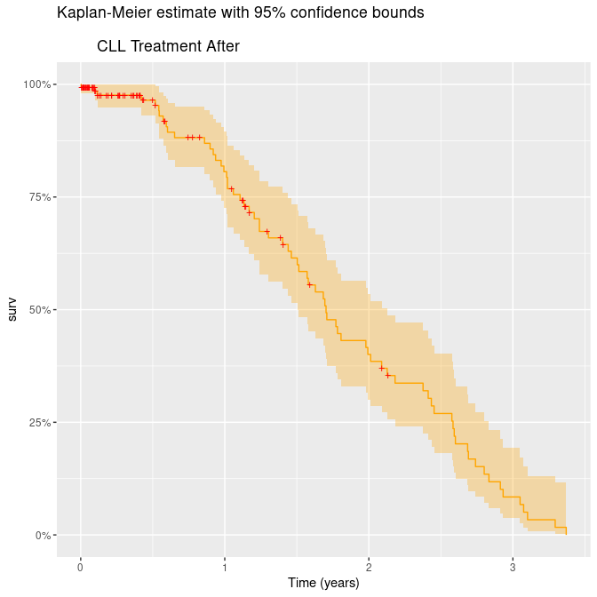

```r
> CLL_metadata.survival$survivalTreatment <- Surv(time = CLL_metadata.survival$TTT,
+     event = CLL_metadata.survival$treatedAfter == "Treat")
> my.treat <- survfit(CLL_metadata.survival$survivalTreatment ~
+     1)
> autoplot(my.treat, surv.colour = "orange", censor.colour = "red",
+     main = "Kaplan-Meier estimate with 95% confidence bounds\n
+          CLL Treatment After",
+     xlab = "Time (years)")
```

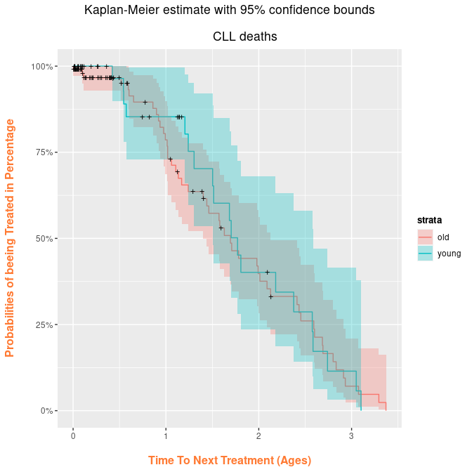

```r
> my.fit2 <- survfit(CLL_metadata.survival$survivalTreatment ~
+     as.factor(CLL_metadata.survival$grouping_age))
> autoplot(my.fit2) + labs(x = "\n Time To Next Treatment (Ages) ",
+     y = " Probabilities of beeing Treated in Percentage \n",
+     title = "Kaplan-Meier estimate with 95% confidence bounds\n
+          CLL deaths") +
+     theme(plot.title = element_text(hjust = 0.5), axis.title.x = element_text(face = "bold",
+         colour = "#FF7A33", size = 12), axis.title.y = element_text(face = "bold",
+         colour = "#FF7A33", size = 12), legend.title = element_text(face = "bold",
+         size = 10))
```

```r
> survdiff(CLL_metadata.survival$survivalTreatment ~ as.factor(CLL_metadata.survival$grouping_age))
```

```
Call:
survdiff(formula = CLL_metadata.survival$survivalTreatment ~
    as.factor(CLL_metadata.survival$grouping_age))

                                                      N Observed Expected
as.factor(CLL_metadata.survival$grouping_age)=old   107       49     48.3
as.factor(CLL_metadata.survival$grouping_age)=young  45       20     20.7
                                                    (O-E)^2/E (O-E)^2/V
as.factor(CLL_metadata.survival$grouping_age)=old      0.0094     0.032
as.factor(CLL_metadata.survival$grouping_age)=young    0.0220     0.032

 Chisq= 0  on 1 degrees of freedom, p= 0.9
```

We do not observe any differences between Kaplan Meier curves for old and young people if they were trated or not

## 3.3 By gender

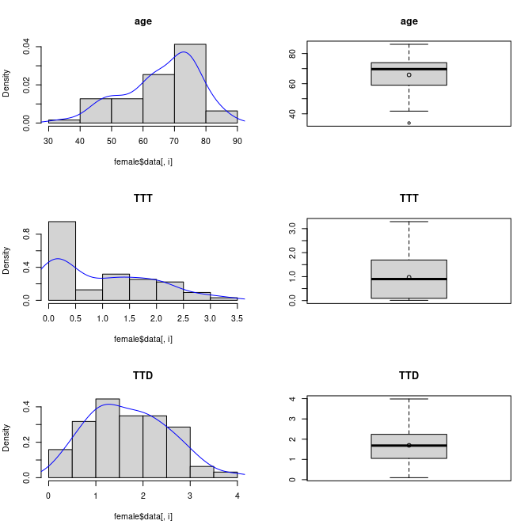

```r
> sumarizacion <- function(datos, columna, grupo) {
+     if (columna == "gender") {
+         datos.grupo <- datos[datos$Gender == grupo, ]
+         datos.grupo$Gender <- droplevels(datos.grupo$Gender)
+     } else if (columna == "tratamiento") {
+         datos.grupo <- datos[datos$treatedAfter == grupo, ]
+         datos.grupo$treatedAfter <- droplevels(datos.grupo$treatedAfter)
+     } else if (columna == "mutacion") {
+         datos.grupo <- datos[datos$IGHV == grupo, ]
+         datos.grupo$IGHV <- droplevels(datos.grupo$IGHV)
+
+     } else if (columna == "trisomia") {
+         datos.grupo <- datos[datos$trisomy12 == grupo, ]
+         datos.grupo$trisomy12 <- droplevels(datos.grupo$trisomy12)
+
+     }
+
+
+     s <- summary(datos.grupo)
+     s[is.na(s)] <- ""
+     s <- s[, -c(1, ncol(s) - 1, ncol(s))]
+     lista <- list(summary = s, data = datos.grupo)
+     return(lista)
+
+
+ }
> female <- sumarizacion(CLL_metadata.copy, "gender", "f")
>
> par(mfrow = c(3, 2))
> for (i in 1:ncol(female$data)) {
+
+     if (class(female$data[, i]) == "numeric") {
+
+         hist(female$data[, i], main = colnames(female$data)[i],
+             freq = F)
+         lines(density(female$data[, i]), col = "blue")
+         boxplot(female$data[, i], main = colnames(female$data)[i])
+         points(mean(female$data[, i]))
+
+
+     }
+
+ }
```

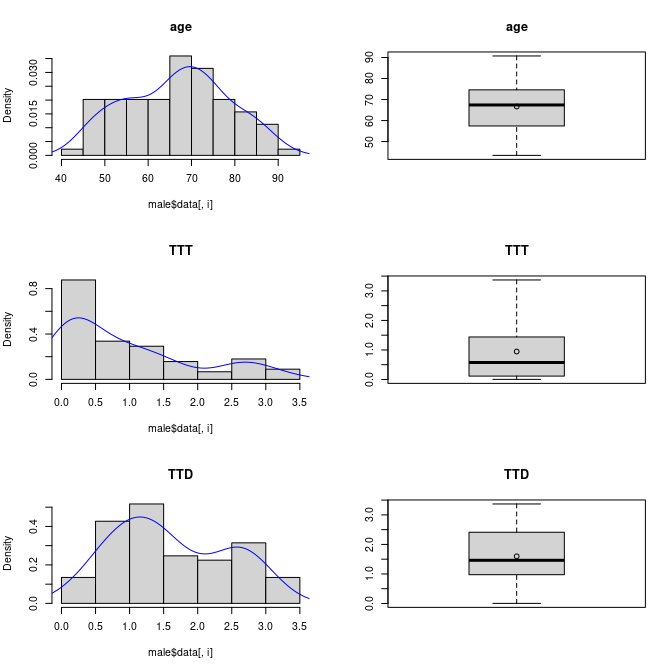

```r
> male <- sumarizacion(CLL_metadata.copy, "gender", "m")
>
> par(mfrow = c(3, 2))
> for (i in 1:ncol(male$data)) {
+
+     if (class(male$data[, i]) == "numeric") {
+
+         hist(male$data[, i], main = colnames(male$data)[i], freq = F)
+         lines(density(male$data[, i]), col = "blue")
+         boxplot(male$data[, i], main = colnames(male$data)[i])
+         points(mean(male$data[, i]))
+
+
+     }
+
+ }
```

## 3.4 By treatment

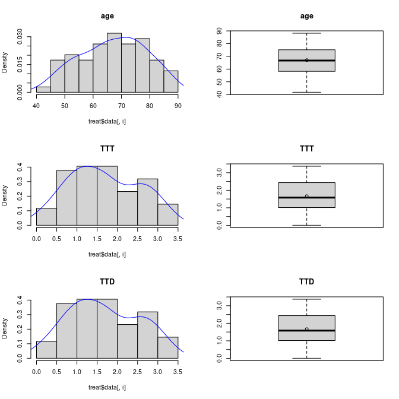

```r
> treat <- sumarizacion(CLL_metadata.copy, "tratamiento", "Treat")
>
> par(mfrow = c(3, 2))
> for (i in 1:ncol(treat$data)) {
+
+     if (class(treat$data[, i]) == "numeric") {
+
+         hist(treat$data[, i], main = colnames(treat$data)[i],
+             freq = F)
+         lines(density(treat$data[, i]), col = "blue")
+         boxplot(treat$data[, i], main = colnames(treat$data)[i])
+         points(mean(treat$data[, i]))
+
+
+     }
+
+ }
```

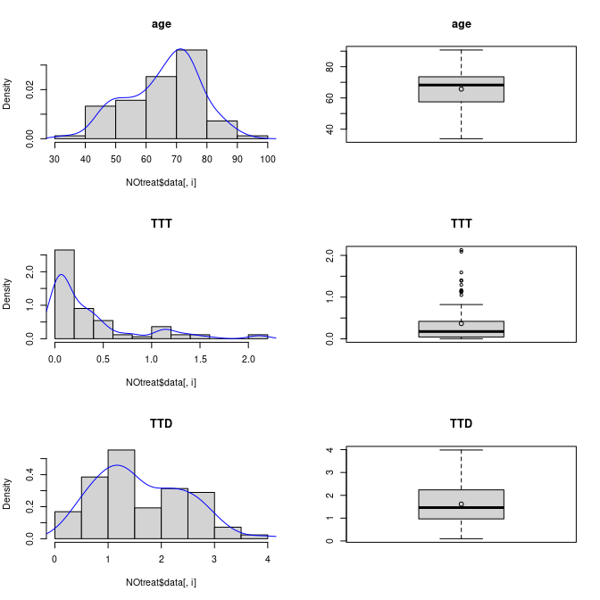

```r
> NOtreat <- sumarizacion(CLL_metadata.copy, "tratamiento", "NoTreat")
>
> par(mfrow = c(3, 2))
> for (i in 1:ncol(NOtreat$data)) {
+
+     if (class(NOtreat$data[, i]) == "numeric") {
+
+         hist(NOtreat$data[, i], main = colnames(NOtreat$data)[i],
+             freq = F)
+         lines(density(NOtreat$data[, i]), col = "blue")
+         boxplot(NOtreat$data[, i], main = colnames(NOtreat$data)[i])
+         points(mean(NOtreat$data[, i]))
+
+
+     }
+
+ }
```

## 3.5 By trisomy

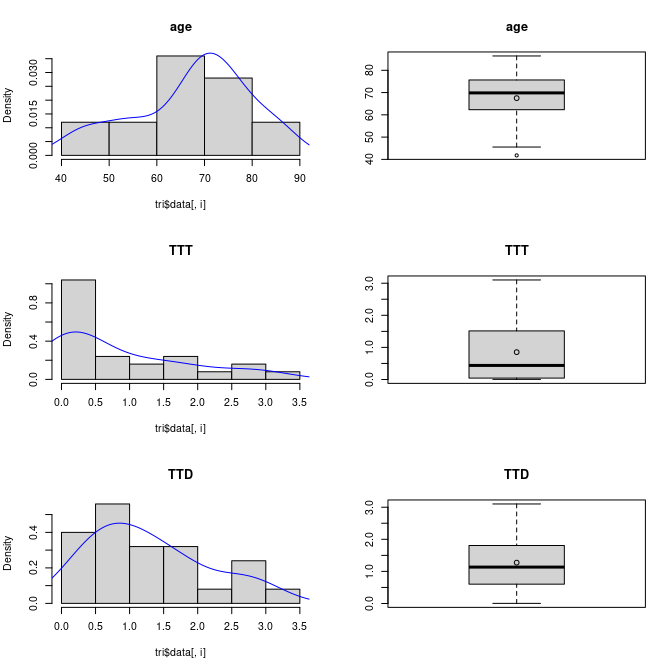

```r
> tri <- sumarizacion(CLL_metadata.copy, "trisomia", "tri")
>
> par(mfrow = c(3, 2))
> for (i in 1:ncol(tri$data)) {
+
+     if (class(tri$data[, i]) == "numeric") {
+
+         hist(tri$data[, i], main = colnames(tri$data)[i], freq = F)
+         lines(density(tri$data[, i]), col = "blue")
+         boxplot(tri$data[, i], main = colnames(tri$data)[i])
+         points(mean(tri$data[, i]))
+
+
+     }
+
+ }
```

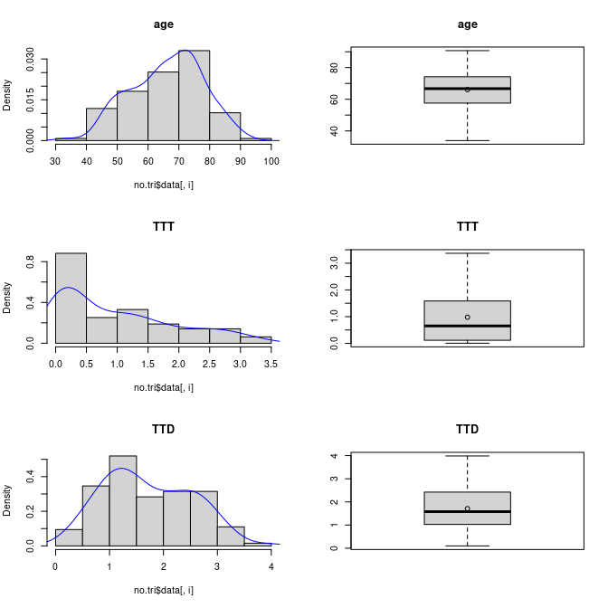

```r
> no.tri <- sumarizacion(CLL_metadata.copy, "trisomia", "norm")
>
> par(mfrow = c(3, 2))
> for (i in 1:ncol(no.tri$data)) {
+
+     if (class(no.tri$data[, i]) == "numeric") {
+
+         hist(no.tri$data[, i], main = colnames(no.tri$data)[i],
+             freq = F)
+         lines(density(no.tri$data[, i]), col = "blue")
+         boxplot(no.tri$data[, i], main = colnames(no.tri$data)[i])
+         points(mean(no.tri$data[, i]))
+
+
+     }
+
+ }
```

## By mutation

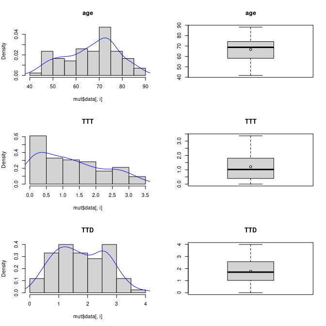

```r
> mut <- sumarizacion(CLL_metadata.copy, "mutacion", "mut")
>
> par(mfrow = c(3, 2))
> for (i in 1:ncol(mut$data)) {
+
+     if (class(mut$data[, i]) == "numeric") {
+
+         hist(mut$data[, i], main = colnames(mut$data)[i], freq = F)
+         lines(density(mut$data[, i]), col = "blue")
+         boxplot(mut$data[, i], main = colnames(mut$data)[i])
+         points(mean(mut$data[, i]))
+
+
+     }
+
+ }
```

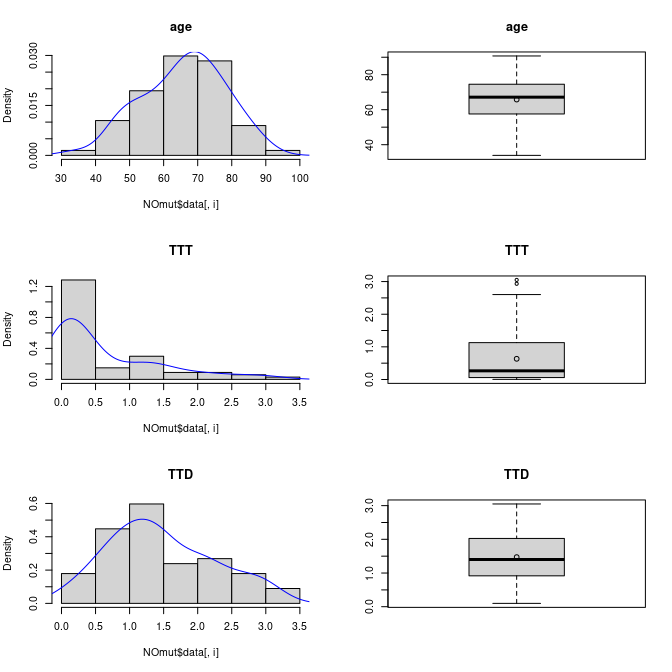

```r
> NOmut <- sumarizacion(CLL_metadata.copy, "mutacion", "NOmut")
>
> par(mfrow = c(3, 2))
> for (i in 1:ncol(NOmut$data)) {
+
+     if (class(NOmut$data[, i]) == "numeric") {
+
+         hist(NOmut$data[, i], main = colnames(NOmut$data)[i],
+             freq = F)
+         lines(density(NOmut$data[, i]), col = "blue")
+         boxplot(NOmut$data[, i], main = colnames(NOmut$data)[i])
+         points(mean(NOmut$data[, i]))
+
+
+     }
+
+ }
```

## 3.6 Comparison Trisomy-NoTrisomy

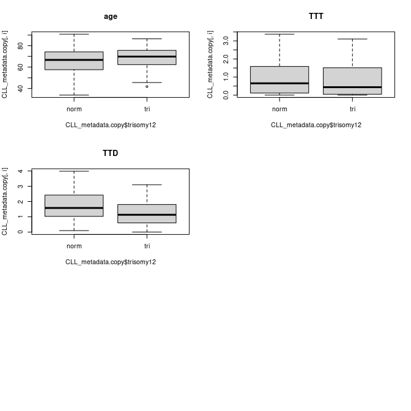

```r
> par(mfrow = c(3, 2))
> for (i in 1:ncol(CLL_metadata.copy)) {
+
+     if (class(CLL_metadata.copy[, i]) == "numeric") {
+
+         boxplot(CLL_metadata.copy[, i] ~ CLL_metadata.copy$trisomy12,
+             main = colnames(CLL_metadata.copy)[i])
+
+
+     }
+
+ }
```

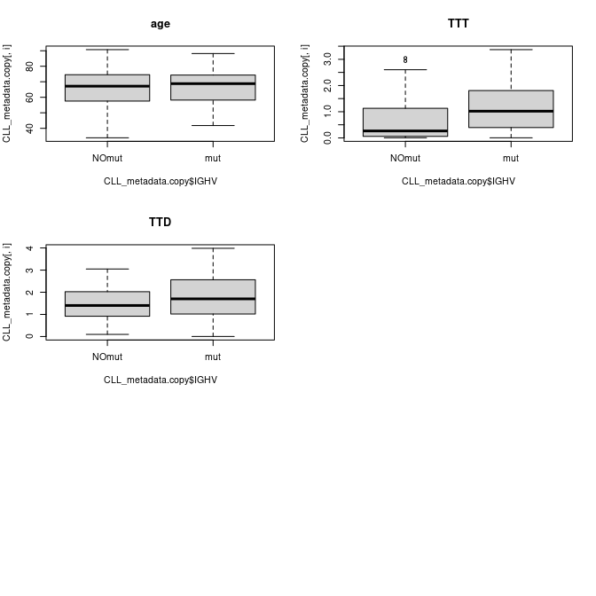

```r
> par(mfrow = c(3, 2))
> for (i in 1:ncol(CLL_metadata.copy)) {
+
+     if (class(CLL_metadata.copy[, i]) == "numeric") {
+
+         boxplot(CLL_metadata.copy[, i] ~ CLL_metadata.copy$IGHV,
+             main = colnames(CLL_metadata.copy)[i])
+
+
+     }
+
+ }
```

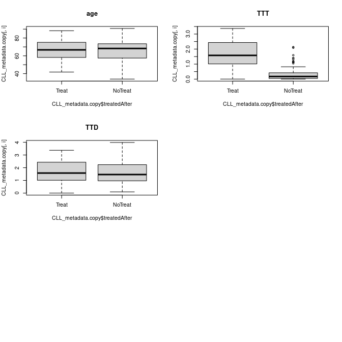

```r
> par(mfrow = c(3, 2))
> for (i in 1:ncol(CLL_metadata.copy)) {
+
+     if (class(CLL_metadata.copy[, i]) == "numeric") {
+
+         boxplot(CLL_metadata.copy[, i] ~ CLL_metadata.copy$treatedAfter,
+             main = colnames(CLL_metadata.copy)[i])
+
+
+     }
+
+ }
```

## 3.8 Comparison Trisomy-Mutation

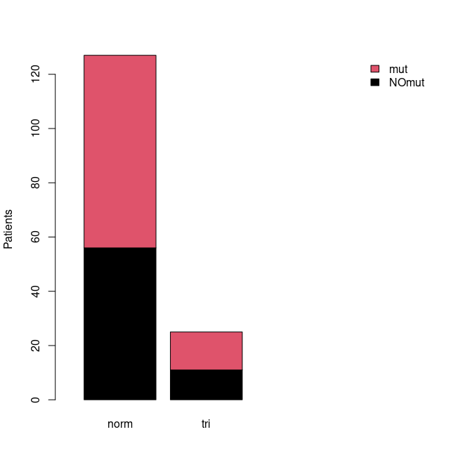

```r
> grupo <- table(CLL_metadata.copy$IGHV, CLL_metadata.copy$trisomy12)
> y <- list(grupo = grupo)
> par(mfrow = c(1, 1))
> for (i in 1:length(y)) {
+     y.t <- y[[i]]
+     barplot(y.t, xlim = c(0, ncol(y.t) + 3), col = 1:2, ylab = "Patients",
+         legend.text = T, args.legend = list(x = ncol(y.t) + 3,
+             y = max(colSums(y.t)), bty = "n"))
+
+
+ }
```

## 3.9 Clinical Association between variables

```r
> perm.test.cor <- function(x, y, num.sim = 100, datos = CLL_metadata.survival) {
+
+     test.stat0 <- survcorr(x ~ 1, y ~ 1, data = datos)$rho
+     test.stat <- NULL
+     for (i in 1:num.sim) {
+
+         test.stat <- c(test.stat, survcorr(x ~ 1, y ~ 1, data = datos)$rho)
+
+     }
+     p.value <- mean(abs(test.stat) >= abs(test.stat0))
+     return(p.value)
+
+ }
>
>
>
>
> variables <- c("age", "Gender", "IGHV", "trisomy12", "survivalOutcome",
+     "survivalTreatment")
>
> asociationClinicalVariables <- function(variables, logaritmo) {
+
+     clinical.variables <- CLL_metadata.survival[, variables]
+
+     pvalues <- matrix(numeric(length = (ncol(clinical.variables))^2),
+         ncol = ncol(clinical.variables), nrow = ncol(clinical.variables))
+
+     SO <- Surv(CLL_metadata.copy$TTD, as.numeric(CLL_metadata.copy$died))
+     ST <- Surv(CLL_metadata.copy$TTT, as.numeric(CLL_metadata.copy$treatedAfter))
+
+
+     for (i in 1:ncol(clinical.variables)) {
+
+         for (j in 1:ncol(clinical.variables)) {
+
+             # print(c(i,j))
+
+             # print(c(names(clinical.variables)[i],names(clinical.variables)[j]))
+
+             if ((class(clinical.variables[, i]) == "factor") &&
+                 (class(clinical.variables[, j]) == "factor")) {
+
+
+                 ch <- chisq.test(clinical.variables[, i], clinical.variables[,
+                   j])
+                 if (any(ch$expected < 5)) {
+
+                   pvalues[i, j] <- fisher.test(clinical.variables[,
+                     i], clinical.variables[, j])$p.value
+
+                 } else {
+
+                   pvalues[i, j] <- ch$p.value
+                 }
+
+
+             } else if ((class(clinical.variables[, i]) == "factor") &&
+                 (class(clinical.variables[, j]) == "numeric")) {
+
+                 pvalues[i, j] <- wilcox.test(clinical.variables[,
+                   j] ~ clinical.variables[, i])$p.value
+
+             } else if ((class(clinical.variables[, i]) == "numeric") &&
+                 (class(clinical.variables[, j]) == "factor")) {
+
+                 pvalues[i, j] <- wilcox.test(clinical.variables[,
+                   i] ~ clinical.variables[, j])$p.value
+
+             } else if ((class(clinical.variables[, i]) == "Surv") &&
+                 (class(clinical.variables[, j]) == "numeric")) {
+                 pvalues[i, j] <- summary(coxph(clinical.variables[,
+                   i] ~ clinical.variables[, j]))$coefficients[5]
+             } else if ((class(clinical.variables[, i]) == "numeric") &&
+                 (class(clinical.variables[, j]) == "Surv")) {
+                 pvalues[i, j] <- summary(coxph(clinical.variables[,
+                   j] ~ clinical.variables[, i]))$coefficients[5]
+
+             } else if ((class(clinical.variables[, i]) == "Surv") &&
+                 (class(clinical.variables[, j]) == "factor")) {
+
+
+                 pvalues[i, j] <- summary(coxph(clinical.variables[,
+                   i] ~ clinical.variables[, j]))$coefficients[5]
+
+
+             } else if ((class(clinical.variables[, i]) == "factor") &&
+                 (class(clinical.variables[, j]) == "Surv")) {
+
+                 pvalues[i, j] <- summary(coxph(clinical.variables[,
+                   j] ~ clinical.variables[, i]))$coefficients[5]
+
+             } else if ((class(clinical.variables[, i]) == "numeric") &&
+                 (class(clinical.variables[, j]) == "numeric")) {
+                 pvalues[i, j] <- cor.test(clinical.variables[,
+                   i], clinical.variables[, j], method = "spearman")$p.value
+             } else if ((class(clinical.variables[, i]) == "Surv") &&
+                 (class(clinical.variables[, j]) == "Surv")) {
+
+                 if ((colnames(clinical.variables)[i] == colnames(clinical.variables)[j])) {
+
+                   if (colnames(clinical.variables)[i] == "survivalOutcome") {
+                     pvalues[i, j] <- perm.test.cor(SO, SO)
+                   } else {
+                     pvalues[i, j] <- perm.test.cor(SO, SO)
+                   }
+
+
+
+
+                 } else {
+
+                   if (colnames(clinical.variables)[i] == "survivalOutcome") {
+
+                     pvalues[i, j] <- perm.test.cor(SO, ST)
+
+                   } else {
+
+                     pvalues[i, j] <- perm.test.cor(ST, SO)
+                   }
+
+                 }
+
+
+             }
+         }
+     }
+
+
+     diag(pvalues) <- 1
+     if (logaritmo == T) {
+
+         matriz.df <- as.data.frame((-log10(pvalues)))
+         colnames(matriz.df) <- colnames(clinical.variables)
+         rownames(matriz.df) <- colnames(clinical.variables)
+         ggcorrplot(matriz.df, lab = T) + scale_fill_gradient2(limit = c(0,
+             5), name = "-log10(pvalue)")
+
+
+     } else {
+
+         matriz.df <- as.data.frame(pvalues)
+         colnames(matriz.df) <- colnames(clinical.variables)
+         rownames(matriz.df) <- colnames(clinical.variables)
+         ggcorrplot(matriz.df, lab = T) + scale_fill_gradient2(limit = c(0,
+             1), name = "pvalue")
+
+
+     }
+
+
+
+
+ }
```

```r
> asociationClinicalVariables(variables = variables, logaritmo = T)
```

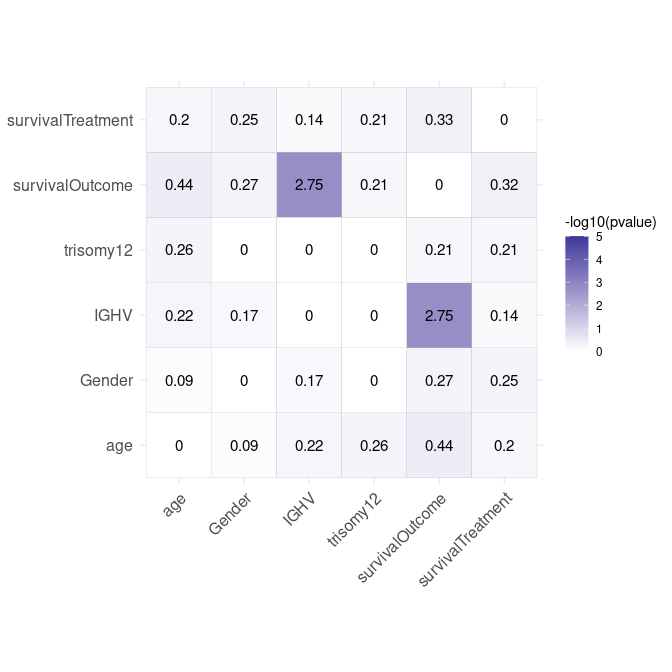

# 4 Individual omics exploration

## 4.1 RNA-seq analysis

Before performing the analysis we must exclude those samples excluded in the metadata analysis, and renaming with the shortName

```r
> mat <- CLL_data$mRNA
> mat <- mat[, order(colnames(mat))]
> mat <- mat[, which(colnames(mat) %in% rownames(CLL_metadata.copy))]
> all(colnames(mat) == rownames(CLL_metadata.copy))
```

```
[1] TRUE
```

```r
> discard.columns <- apply(mat, 2, function(x) any(is.na(x)))
> mat <- mat[, !discard.columns]
> CLL_metadata.copy.mRNA <- CLL_metadata.copy[!discard.columns,
+     ]
```

```r
> dge <- DGEList(counts = mat, genes = rownames(mat))
> keep <- filterByExpr(dge)
> dge_filt <- dge[keep, , keep.lib.sizes = F]
> dge_filt$samples
```

[output not shown]

[output cut: 48 more lines]

```
H231     1 7016.673            1
H233     1 6831.694            1
H234     1 6989.110            1
H236     1 6760.415            1
H238     1 6979.259            1
H239     1 6974.246            1
H240     1 6888.933            1
H243     1 6887.778            1
H246     1 6918.618            1
H247     1 7059.661            1
H249     1 6942.214            1
H257     1 6954.948            1
H260     1 6813.666            1
H270     1 6798.532            1
H271     1 6841.702            1
```

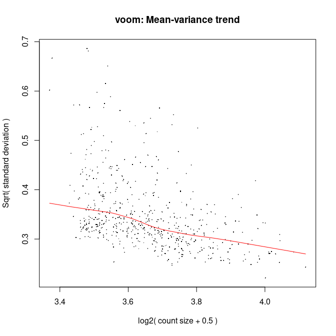

```r
> dge_norm <- calcNormFactors(dge_filt)
> v <- voom(dge_norm, plot = T)
```

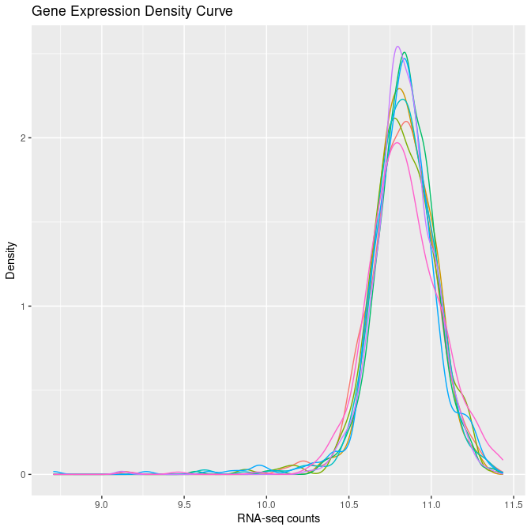

```r
> # Prepare data for distribution plot using ggplot
> sampleNames = vector()
> intensities = vector()
> for (i in 1:8) {
+     sampleNames = c(sampleNames, rep(colnames(v$E)[i], nrow(v$E)))
+     intensities = c(intensities, v$E[, i])
+ }
>
> arrayData <- data.frame(intensities, sampleNames)
>
> g = ggplot(arrayData, aes(intensities, color = sampleNames))
>
> g + geom_density() + theme(legend.position = "none") + labs(title = "Gene Expression Density Curve",
+     x = "RNA-seq counts", y = "Density")
```

```r
> boxplot.function <- function(expresion, datos, variable) {
+     t <- as.data.frame(table(datos[[variable]]))
+     t$colorNum <- 1:dim(t)[1]
+     lista <- NULL
+     for (i in 1:nrow(t)) {
+
+         lista[[i]] <- rep(i, t$Freq[i])
+
+
+     }
+     colores <- unlist(lista)
+
+     boxplot(expresion, cex.axis = 0.5, las = 2, which = "all",
+         col = colores, main = "Distribution of log counts", names = rownames(datos))
+
+     legend("bottomleft", inset = 0.02, title = variable, legend = levels(datos[[variable]]),
+         fill = 1:length(levels(datos[[variable]])), horiz = F,
+         cex = 0.8)
+
+ }
```

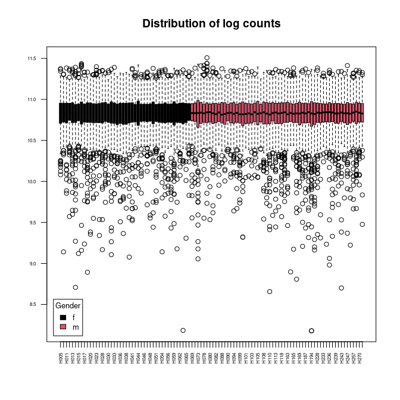

```r
> boxplot.function(v$E, CLL_metadata.copy.mRNA, "Gender")
```

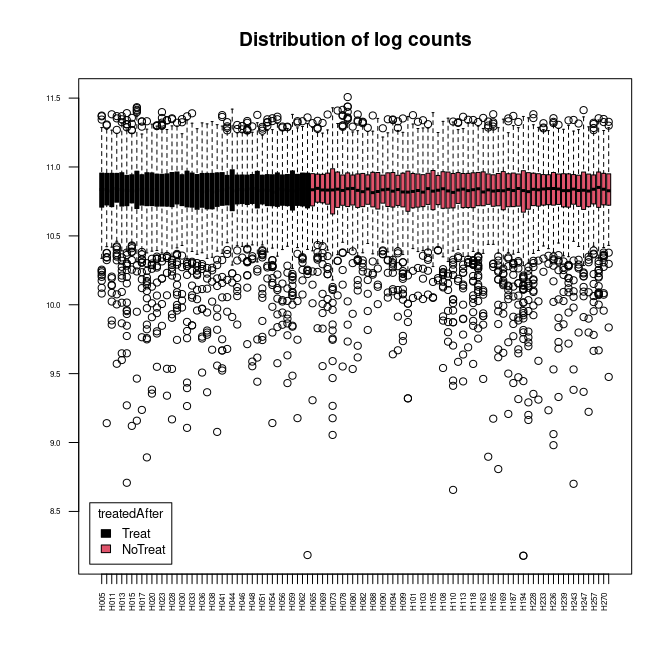

```r
> boxplot.function(v$E, CLL_metadata.copy.mRNA, "treatedAfter")
```

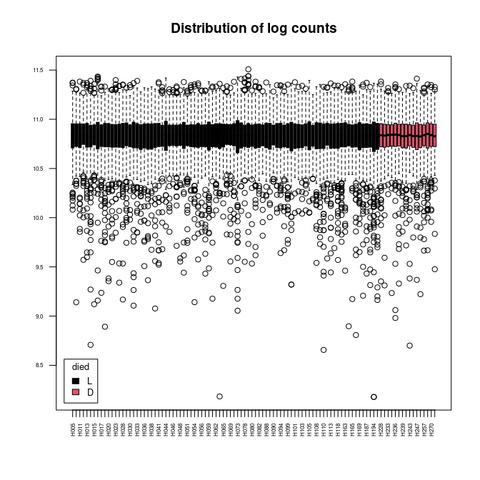

```r
> boxplot.function(v$E, CLL_metadata.copy.mRNA, "died")
```

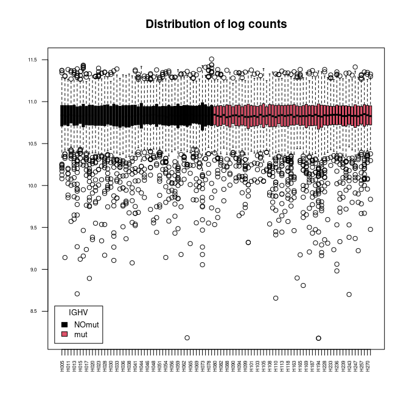

```r
> boxplot.function(v$E, CLL_metadata.copy.mRNA, "IGHV")
```

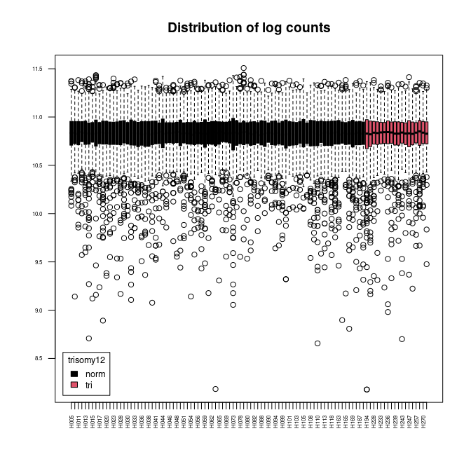

```r
> boxplot.function(v$E, CLL_metadata.copy.mRNA, "trisomy12")
```

```r
> pca_rna <- prcomp(t(v$E), center = T, scale = F)
>
> plot.pca.variance <- function(pca_type, tipo) {
+
+
+     var_prcomp <- pca_type$sdev^2
+
+     # Plot PCs variance
+     pcvar <- data.frame(var = var_prcomp/sum(var_prcomp) * 100,
+         pc = c(1:length(var_prcomp)))
+
+     ggplot(pcvar, aes(x = pc)) + geom_line(aes(y = var)) + labs(x = "Principal Component",
+         y = "Explained Variance") + geom_point(aes(y = var)) +
+         ggtitle(paste0(tipo, " Principal Components variance"))
+
+ }
```

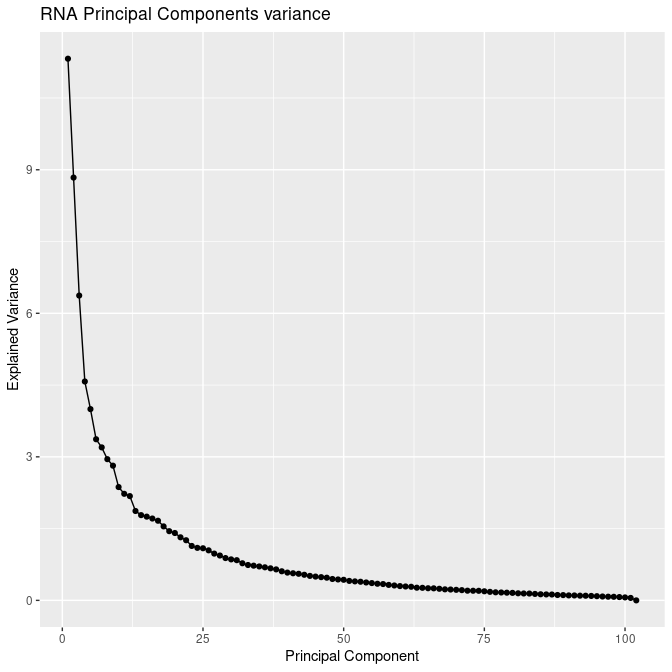

```r
> plot.pca.variance(pca_rna, "RNA")
```

```r
> plotPCA3 <- function(pca_type, labels, factor, title, size = 1.5,
+     glineas = 0.25) {
+     if (missing(labels)) {
+         labels.T = F
+     } else {
+         lables.T = T
+     }
+     data <- pca_type
+     # plot adjustments
+     dataDf <- data.frame(data$x)
+     Group <- factor
+     loads <- round(data$sdev^2/sum(data$sdev^2) * 100, 2)
+     colores <- 1:length(levels(Group))
+     # main plot
+     p1 <- ggplot(dataDf, aes(x = PC1, y = PC2)) + theme_classic() +
+         geom_hline(yintercept = 0, color = "gray70") + geom_vline(xintercept = 0,
+         color = "gray70") + geom_point(aes(color = Group), alpha = 0.55,
+         size = 3) + coord_cartesian(xlim = c(min(data$x[, 1]) -
+         5, max(data$x[, 1]) + 5)) + scale_fill_discrete(name = "Group")
+     # avoiding labels superposition
+     if (labels.T == T) {
+         grafico <- p1 + geom_text_repel(aes(y = PC2 + 0.25, label = labels),
+             segment.size = 0.25, size = size) + labs(x = c(paste("PC1",
+             loads[1], "%")), y = c(paste("PC2", loads[2], "%"))) +
+             ggtitle(paste("Principal Component Analysis for: ",
+                 title, sep = " ")) + theme(plot.title = element_text(hjust = 0.5)) +
+             scale_color_manual(values = colores)
+     } else if (labels.T == F) {
+         grafico <- p1 + labs(x = c(paste("PC1", loads[1], "%")),
+             y = c(paste("PC2", loads[2], "%"))) + ggtitle(paste("Principal Component Analysis for: ",
+             title, sep = " ")) + theme(plot.title = element_text(hjust = 0.5)) +
+             scale_color_manual(values = colores)
+     }
+
+     return(grafico)
+
+ }
```

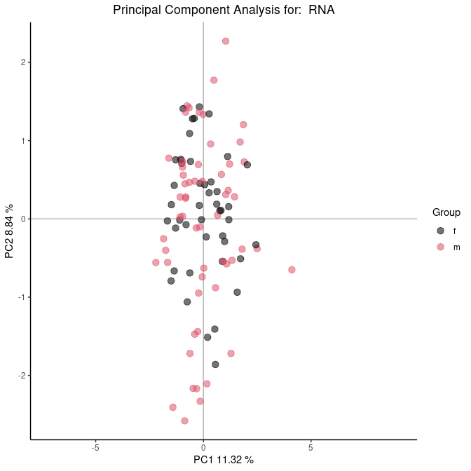

```r
> plotPCA3(pca_rna, factor = CLL_metadata.copy.mRNA$Gender, title = "RNA")
```

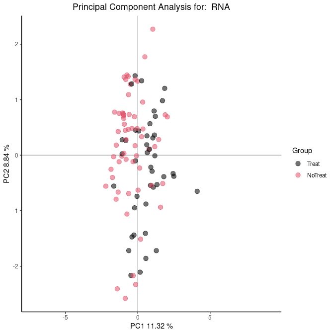

```r
> plotPCA3(pca_rna, factor = CLL_metadata.copy.mRNA$treatedAfter,
+     title = "RNA")
```

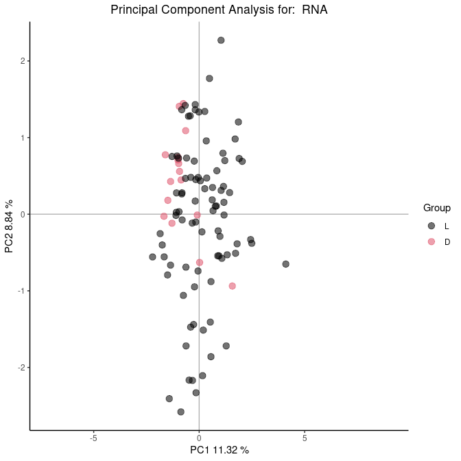

```r
> plotPCA3(pca_rna, factor = CLL_metadata.copy.mRNA$died, title = "RNA")
```

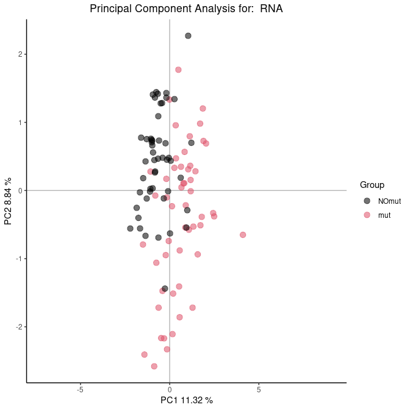

```r
> plotPCA3(pca_rna, factor = CLL_metadata.copy.mRNA$IGHV, title = "RNA")
```

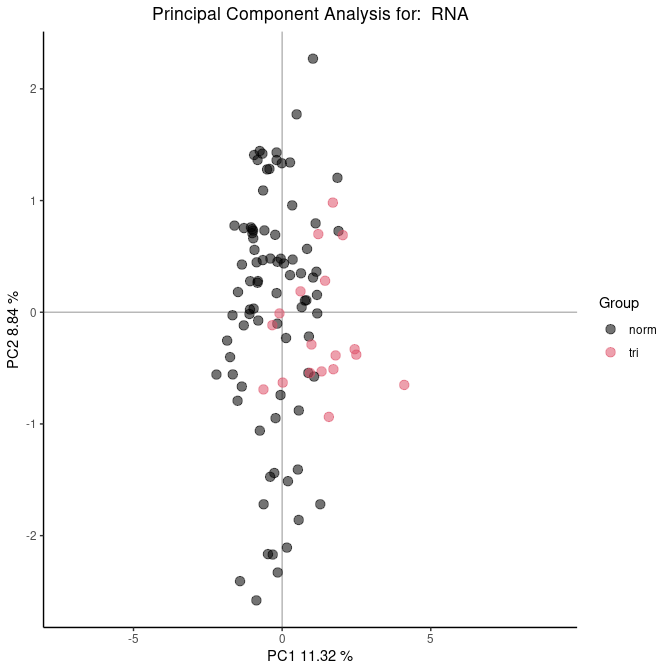

```r
> plotPCA3(pca_rna, factor = CLL_metadata.copy.mRNA$trisomy12,
+     title = "RNA")
```

```r
> variables <- c("age", "Gender", "IGHV", "trisomy12", "treatedAfter",
+     "died", "TTT", "TTD", "survivalOutcome", "survivalTreatment")
> pcaCorrelation <- function(pca_type, expresion, variables, pca_num) {
+
+     clinical.variables <- CLL_metadata.survival[, variables]
+     clinical.variables.type <- clinical.variables[colnames(expresion),
+         ]
+     loads <- pca_type$x
+
+     pvalues_type <- matrix(0, ncol = pca_num, nrow = ncol(clinical.variables.type))
+     for (j in 1:pca_num) {
+
+
+         for (k in 1:ncol(clinical.variables.type)) {
+
+             if (class(clinical.variables.type[, k]) == "factor") {
+
+                 pvalues_type[k, j] <- wilcox.test(loads[, j] ~
+                   clinical.variables.type[, k])$p.value
+
+             } else if (class(clinical.variables.type[, k]) == "numeric") {
+                 pvalues_type[k, j] <- cor.test(loads[, j], clinical.variables.type[,
+                   k], method = "spearman")$p.value
+             } else if (class(clinical.variables.type[, k]) == "Surv") {
+
+                 s <- summary(coxph(formula = clinical.variables.type$survivalOutcome ~
+                   loads[, j]))
+                 pvalues_type[k, j] <- s$coefficients[, 5]
+             }
+
+
+         }
+
+
+
+     }
+
+     pvalues_type <- as.data.frame(pvalues_type)
+     rownames(pvalues_type) <- colnames(clinical.variables)
+     colnames(pvalues_type) <- colnames(loads)[1:pca_num]
+     return(pvalues_type)
+ }
>
>
>
> plotPCAcorrelation <- function(matriz, logtype, pcaNumber) {
+
+     if (logtype == T) {
+
+         matriz.df <- as.data.frame((-log10(matriz[, 1:pcaNumber])))
+         ggcorrplot(t(matriz.df), lab = T) + scale_fill_gradient2(limit = c(0,
+             10), name = "-log10(pvalue)")
+
+     } else {
+         matriz.df <- as.data.frame(matriz[, 1:pcaNumber])
+         ggcorrplot(t(matriz.df), lab = T) + scale_fill_gradient2(limit = c(0,
+             1), name = "pvalue")
+
+     }
+
+
+ }
```

```r
> matriz_pvalores <- pcaCorrelation(pca_rna, v$E, variables, pca_num = 10)
```

[output not shown]

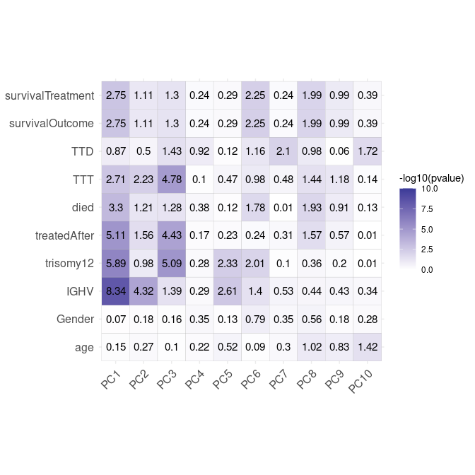

```r
> plotPCAcorrelation(matriz_pvalores, logtype = T, pcaNumber = 10)
```